# R collection

meeting

2020/5/2

## **Vector**

> 1. **simple patterned vectors**
- construct a vecctor

```r
seq(1, 5)
```

```
## [1] 1 2 3 4 5
```

```r
rep(3, 12)
```

```
##  [1] 3 3 3 3 3 3 3 3 3 3 3 3
```

先用NA建一個空的vector會比較清楚

```r
a <- c(3,5,9,10)
V <- rep(NA, 7)
V[1:4] <- a
V
```

```
## [1]  3  5  9 10 NA NA NA
```

- unique()回傳所有不重複的元素

```r
b <- c(3, 3, 3, 3, 5, 5, 1, 2, 10, 10, 8)
unique(b)
```

```
## [1]  3  5  1  2 10  8
```

- table()計算vector中的元素各有幾個

```r
table(b)
```

```
## b
##  1  2  3  5  8 10
##  1  1  4  2  1  2
```

- union()為聯集 `B <- c(3, 1, 5, 4, 7)` `C <- c(23, 1, 44, 5, 3)`

```r
union(B, C)
```

```
## [1]  3  1  5  4  7 23 44
```

- intersect()

```r
intersect(B, C)
```

```
## [1] 3 1 5
```

- sort(x, decreasing = False, …) 回傳排序後的元素

`a <- c(3, 4, 2, 7, 10, 23, 8, 9, 11)`

```r
sort(a)
```

```
## [1]  2  3  4  7  8  9 10 11 23
```

```r
sort(a, decreasing = TRUE)
```

```
## [1] 23 11 10  9  8  7  4  3  2
```

- order(…, na.list = TRUE, decreasing = FALSE) 回傳排序後的元素`編號`

```r
order(a)
```

```
## [1] 3 1 2 4 7 8 5 9 6
```

```r
order(a, decreasing = TRUE)
```

```
## [1] 6 9 5 8 7 4 2 1 3
```

- **changing** values in a vector can

```r
a[5] <- -3
a[8] <- -1
a
```

```
## [1]  3  4  2  7 -3 23  8 -1 11
```

- **deleting** element from a vector

  刪掉該位置的元素

```r
a[-2]
```

```
## [1]  3  2  7 -3 23  8 -1 11
```

```r
a[-c(3:6)]
```

```
## [1]  3  4  8 -1 11
```

- **“is.”** series

is.integer is.numeric is.double is.character

```r
is.null(c())
```

```
## [1] TRUE
```

```r
x1 <- 1:5
x3 <- colors
c(is.integer(x1), is.numeric(x1), is.double(x1))
```

```
## [1]  TRUE  TRUE FALSE
```

```r
c(is.character(x3), is.numeric(x3))
```

```
## [1] FALSE FALSE
```

as.numeric

```r
c(TRUE, FALSE, T, F)
```

```
## [1]  TRUE FALSE  TRUE FALSE
```

```r
c(3<5, 3>5, 3==5, 3!=5)
```

```
## [1]  TRUE FALSE FALSE  TRUE
```

```r
logical <- c(3<5, 3>5, 3==5, 3!=5)
logical
```

```
## [1]  TRUE FALSE FALSE  TRUE
```

```r
logical == TRUE
```

```
## [1]  TRUE FALSE FALSE  TRUE
```

```r
as.numeric(logical)
```

```
## [1] 1 0 0 1
```

```r
sum(logical == TRUE)  ## logical裡有幾個TRUE
```

```
## [1] 2
```

```r
sum(logical)  ## 相當於sum(logical == TRUE)
```

```
## [1] 2
```

is.na

```r
B <- c(2, NA, 5 , 10)
is.na(B)
```

```
## [1] FALSE  TRUE FALSE FALSE
```

```r
# TRUE
which(is.na(B))
```

```
## [1] 2
```

```r
which(is.na(B) == 1)
```

```
## [1] 2
```

```r
ind.T <- which(is.na(B))
B1 <- B[-ind.T]
B1
```

```
## [1]  2  5 10
```

```r
# FALSE
which(!is.na(B))
```

```
## [1] 1 3 4
```

```r
which(is.na(B) == 0)
```

```
## [1] 1 3 4
```

**<Example 1>**

```r
A <- c(3, 4, NA, 12, 0.2, NA, -2)
B <- c(3, 5, "red", 4, NA)
# (1)
is.numeric(A)
```

```
## [1] TRUE
```

```r
is.numeric(B)
```

```
## [1] FALSE
```

```r
# (2)
sum(is.na(A))
```

```
## [1] 2
```

```r
sum(is.na(B))
```

```
## [1] 1
```

```r
# (3)
which(is.na(A))
```

```
## [1] 3 6
```

```r
which(is.na(B))
```

```
## [1] 5
```

```r
# (4)
which(A < 1)
```

```
## [1] 5 7
```

```r
which(B < 1)
```

```
## integer(0)
```

```r
which(B < 5)
```

```
## [1] 1 4
```

- class

```r
a <- c(3, 4, 2, 7, 10, 23, 8, 9, 11)
b <- c("red", "yellow", "blue")
c <- c(TRUE, FALSE)
c(class(a), class(b), class(c))
```

```
## [1] "numeric"   "character" "logical"
```

## **matrix**

> 1. **construct a matrix**
- rbind中每個數列代表一列;cbind中每個數列代表一行

```r
a <- 1:5; b <- 6:10;
c <- 11:15; d <- 16:20
M1 <- rbind(a,b,c,d)
M1
```

```
##   [,1] [,2] [,3] [,4] [,5]
## a    1    2    3    4    5
## b    6    7    8    9   10
## c   11   12   13   14   15
## d   16   17   18   19   20
```

```r
M2 <- cbind(a,b,c,d)
M2
```

```
##      a  b  c  d
## [1,] 1  6 11 16
## [2,] 2  7 12 17
## [3,] 3  8 13 18
## [4,] 4  9 14 19
## [5,] 5 10 15 20
```

- `X <- 1:20`

```r
matrix(X, nrow = 4, ncol = 5)
```

```
##      [,1] [,2] [,3] [,4] [,5]
## [1,]    1    5    9   13   17
## [2,]    2    6   10   14   18
## [3,]    3    7   11   15   19
## [4,]    4    8   12   16   20
```

```r
matrix(X, nrow = 5, ncol = 4)
```

```
##      [,1] [,2] [,3] [,4]
## [1,]    1    6   11   16
## [2,]    2    7   12   17
## [3,]    3    8   13   18
## [4,]    4    9   14   19
## [5,]    5   10   15   20
```

```r
matrix(X, nrow = 4, ncol = 5, byrow = TRUE)
```

```
##      [,1] [,2] [,3] [,4] [,5]
## [1,]    1    2    3    4    5
## [2,]    6    7    8    9   10
## [3,]   11   12   13   14   15
## [4,]   16   17   18   19   20
```

```r
matrix(X, nrow = 5, ncol = 4, byrow = TRUE)
```

```
##      [,1] [,2] [,3] [,4]
## [1,]    1    2    3    4
## [2,]    5    6    7    8
## [3,]    9   10   11   12
## [4,]   13   14   15   16
## [5,]   17   18   19   20
```

> 2. features for a matrix

```r
M1
```

```
##   [,1] [,2] [,3] [,4] [,5]
## a    1    2    3    4    5
## b    6    7    8    9   10
## c   11   12   13   14   15
## d   16   17   18   19   20
```

```r
dim(M1)
```

```
## [1] 4 5
```

```r
colnames(M1);rownames(M1)
```

[output not shown]

```r
colnames(M1) <- c("V1", "V2", "V3", "V4", "V5")
dimnames(M1)
```

```
## [[1]]
## [1] "a" "b" "c" "d"
##
## [[2]]
## [1] "V1" "V2" "V3" "V4" "V5"
```

- Extract elements from a matrix

取M1中的第2列第4行的元素

```r
M1[2, 4]
```

```
## [1] 9
```

```r
M1[c(2, 4), 3]
```

```
##  b  d
##  8 18
```

```r
M1[c(2, 4), c(3, 5)]
```

```
##   V3 V5
## b  8 10
## d 18 20
```

```r
M1[c(2,3), ]
```

```
##   V1 V2 V3 V4 V5
## b  6  7  8  9 10
## c 11 12 13 14 15
```

```r
M1[c("b", "c"), ]
```

```
##   V1 V2 V3 V4 V5
## b  6  7  8  9 10
## c 11 12 13 14 15
```

```r
M1[5] #M1[1,2]
```

```
## [1] 2
```

> 3. Evaluation of Matrix
- statistics description

```r
A <- matrix(c(1:5, 7:10), 3, 3)
A
```

```
##      [,1] [,2] [,3]
## [1,]    1    4    8
## [2,]    2    5    9
## [3,]    3    7   10
```

```r
colSums(A)
```

```
## [1]  6 16 27
```

```r
rowSums(A)
```

```
## [1] 13 16 20
```

```r
colMeans(A)
```

```
## [1] 2.000000 5.333333 9.000000
```

```r
rowMeans(A)
```

```
## [1] 4.333333 5.333333 6.666667
```

- transpose

```r
t(A)
```

```
##      [,1] [,2] [,3]
## [1,]    1    2    3
## [2,]    4    5    7
## [3,]    8    9   10
```

- calculation

```r
diag(A)
```

```
## [1]  1  5 10
```

```r
det(A)
```

```
## [1] 7
```

- $A^{-1}$ is an inverse matrix of A: $AA^{−1} = I$

```r
solve(A)
```

```
##            [,1]       [,2]       [,3]
## [1,] -1.8571429  2.2857143 -0.5714286
## [2,]  1.0000000 -2.0000000  1.0000000
## [3,] -0.1428571  0.7142857 -0.4285714
```

- eigen system

```r
D <- matrix(rnorm(9), 3, 3)
eig.D <- eigen(D)
eig.D$values
```

```
## [1]  1.3612162+0.000000i -0.3772713+0.284674i -0.3772713-0.284674i
```

```r
eig.D$vectors
```

```
##                  [,1]                 [,2]                 [,3]
## [1,]  0.9974663830+0i 0.1570116-0.1829494i 0.1570116+0.1829494i
## [2,]  0.0009594893+0i 0.8905935+0.0000000i 0.8905935+0.0000000i
## [3,] -0.0711329325+0i 0.2704169+0.2749451i 0.2704169-0.2749451i
```

4. $\left[ \begin{array}{cc} A & B \\ C & D \\ \end{array} \right]$

## **Control Flow**

> 1. The for() loop

```
`for (index in vector) commands`
```

- notes
  - for迴圈很浪費資源 不一定會比較快
  - 多多善用vector
- **<Example 1>**

Construct a vector as Xn+1 = 2Xn + 3,where X0 = 3, n = 1, 2, 3, 4, 5, 6, 7

```r
vec.X.v1 <- c()
Xn <- 3
for(n in 1:7){
Xn <- 2*Xn + 3
vec.X.v1 <- c(vec.X.v1, Xn)
}
vec.X.v1
```

```
## [1]   9  21  45  93 189 381 765
```

- **<Example 2>**

n! = n ∗ (n − 1) ∗ (n − 2) ∗ · · · ∗ 2 ∗ 1

```r
# Try n = 10.
n <- 10
ans <- 1
for(j in n:1){
ans <- ans * j
}
ans
```

```
## [1] 3628800
```

```r
factorial(n)
```

```
## [1] 3628800
```

- **<Example 3>**

Find the first 12 values in the Fibonacci sequence. Let F1 = 1 and F2 = 1.

Fn+2 = Fn+1 + Fn, n = 1, 2, 3, …, 10

```r
f1 <- 1
f2 <- 1
all <- rep(NA, 12)
all[1] <- f1
all[2] <- f2
for(n in 3:12){
  k = f1+f2
  f1 <- f2
  f2 <- k
  all[n] <- k
}
all
```

```
##  [1]   1   1   2   3   5   8  13  21  34  55  89 144
```

> 2. The if() statement

`if (condition) {commands when TRUE}` `if (condition) {commands when TRUE} else {commands when FALSE}`

- **<Example 1>**

```r
a <- 2
b <- 2
if(a == b){
  a*b
  c <- a*b
} else if(a==2){
  c <- 2
} else{
  c <- a+b
}
# R裡的空格沒有意義

if(a==b) c <- a*b
# if只有一個敘述且沒有else才能這樣寫
```

- **<Example 2>**

```r
C <- c(3, 4, NA, 12, 0.2, NA, -2)
for(i in 1:7){
if(is.na(C[i])) print(i)
}
```

```
## [1] 3
## [1] 6
```

```r
na.loc <- c()
for(i in 1:7){
if(is.na(C[i]))
  na.loc <- c(na.loc, i)
}
na.loc
```

```
## [1] 3 6
```

> 3. The while() loop

`while (condition) statements`

```r
j <- 1
while(j <= 8){
print(j)
j <- j + 1
}
```

```
## [1] 1
## [1] 2
## [1] 3
## [1] 4
## [1] 5
## [1] 6
## [1] 7
## [1] 8
```

- **<Example 1>**

```r
runif(1)
```

```
## [1] 0.8731441
```

```r
set.seed(20200503)
t <- c()
while (length(unique(t)) < 6){
  X <- sample(1:6, 1)
  t <- c(t, X)
}

length(t)
```

```
## [1] 10
```

> 4. break & repeat & next
- break `if (condition) break`
- repeat `repeat { statements }`
- next

## **Function**

> 1. source()

`print( ) shows with " " between characters.` `cat() shows without " " between characters.`

```r
x <- c("A", "B", "C", "D")
print(x)
```

```
## [1] "A" "B" "C" "D"
```

```r
cat(x)
```

```
## A B C D
```

> 2. function()
- **<Example 1>**

$f (x) = 3x + 2, x=2,3,4$

```r
f <- function(x){
3*x + 2
}
f(2)
```

```
## [1] 8
```

- `return` in the function()

```r
f <- function(x){
res <- 3*x + 2
}
f(2)
# return nothing
```

```r
f <- function(x){
res <- 3*x + 2
return (res) # return the output
}
f(2)
```

```
## [1] 8
```

> 3. list

`$: the name of the element.` `[[ ]]: the location or the name of the element.`

- **<Example 1>**

```r
X <- list(a = 3, b = c(1:5), c = c("A", "B"))
X
```

```
## $a
## [1] 3
##
## $b
## [1] 1 2 3 4 5
##
## $c
## [1] "A" "B"
```

```r
X$a
```

```
## [1] 3
```

```r
X[[2]]
```

```
## [1] 1 2 3 4 5
```

```r
X[["c"]]
```

```
## [1] "A" "B"
```

- creat a list

```r
try.list <- list() ## a null list
length(try.list)
```

```
## [1] 0
```

```r
length(try.list) <- 2 ## assign the size to the list
try.list[[1]] <- seq(0, 10, length.out = 3) ## without name
try.list$square <- seq(0, 10, length.out = 3)^2 ## with name
try.list
```

```
## [[1]]
## [1]  0  5 10
##
## [[2]]
## NULL
##
## $square
## [1]   0  25 100
```

> 4. Use `invisible( )` to hide some output.

```r
perfect.number <- function(a, b){
k <- a
res <- c()
ans <- list()
while(k < b){
fac <- c()
for(j in 1:k){
if((k %% j) == 0) fac <- c(fac, j)
}
if(k == sum(fac[-length(fac)])) {
res <- c(res, k)
ans[[paste(k)]] <- fac[-length(fac)]
}
k <- k+1
}
print(res)
ans$number <- res
return(invisible(ans)) # do not show the output
}
```

## **Data Frame**

> 1. **`data.frame()`**
- **<Example 1>**

```r
colors <- c("red", "yellow", "blue")
numbers <- c(1, 2, 3)
colors.and.numbers <- data.frame(colors, numbers,
more.numbers = c(4, 5, 6))
colors.and.numbers
```

```
##   colors numbers more.numbers
## 1    red       1            4
## 2 yellow       2            5
## 3   blue       3            6
```

- **difference with matrix**
  - These are like matrices, but with the columns having their own names.
  - Columns can be of different types from each other.
> 2. **types in a data frame: chracter**

Change the type from factor to character by using `stringAsFactors =FALSE`

```r
colors <- c("red", "yellow", "blue")
numbers <- c(1, 2, 3)
colors.and.numbers <- data.frame(colors, numbers,
more.numbers = c(4, 5, 6),
stringsAsFactors = FALSE)
str(colors.and.numbers)
```

```
## 'data.frame':    3 obs. of  3 variables:
##  $ colors      : chr  "red" "yellow" "blue"
##  $ numbers     : num  1 2 3
##  $ more.numbers: num  4 5 6
```

> 3. add rows/columns
- row: use `rbind()`
- column: use the sign `$` or `cbind()`

```r
data2 <- data.frame(colors, numbers, more.numbers = c(4, 5, 6),
stringsAsFactors = FALSE)
data2 <- rbind(data2, c("black", 4, 7))
data2$new.column <- c('a','b','c','d')
data2
```

```
##   colors numbers more.numbers new.column
## 1    red       1            4          a
## 2 yellow       2            5          b
## 3   blue       3            6          c
## 4  black       4            7          d
```

> 4. Data input and output at hard disk
- Change the directory: **`setwd(“dir”)`**
- Find the directory: **`get()`**
- To save all objects in the current workspace, type **`save.image(“XXX.RData”)`**
- To save parts of objects, type **`save(a, b, c, file = “XXX.RData”)`**
- Use **`load(“XXX.RData”)`** to retrieve data.
- Save data to a file
  - **`write.table(A, file = “XXX.txt”)`**
  - **`write.csv(A, file = “XXX.csv”)`**
- Read data from a file
  - **`read.table(file = “XXX.txt”)`**
  - **`read.csv(file = “XXX.csv”)`**
> 5. R Package
- To download a package, type **`install.packages(“XXX”)`**
- Before using some functions in a downloaded package, you should call the package by typing **`library(XXX)`**
> 6. Tools for help
> - typee **`help(name)`** or **`?name`**

## **R Graphics**

> 1. Graphics for descriptive statistics
- Histogram: hist(x)

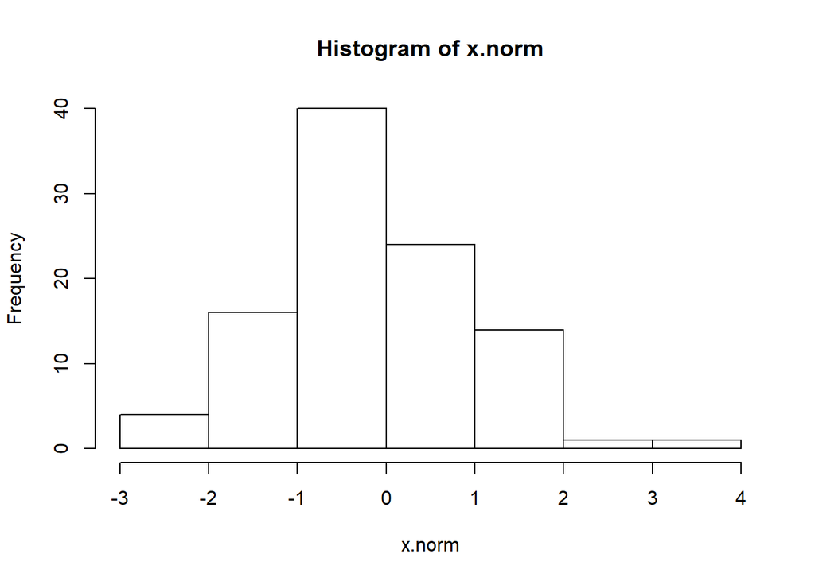

```r
x.norm <- rnorm(100, mean=0, sd=1)
hist(x.norm)
```

- Boxplot: boxplot(x)

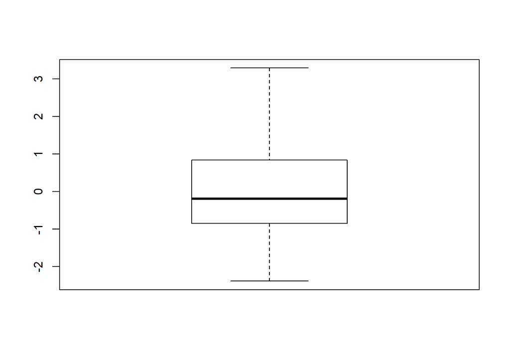

```r
boxplot(x.norm)
```

- Density plot: plot(density(x))

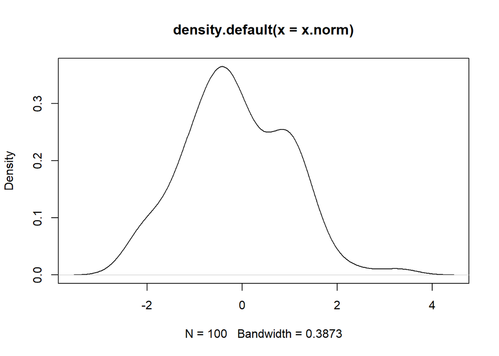

```r
plot(density(x.norm))
```

- Barchart: barplot(x)

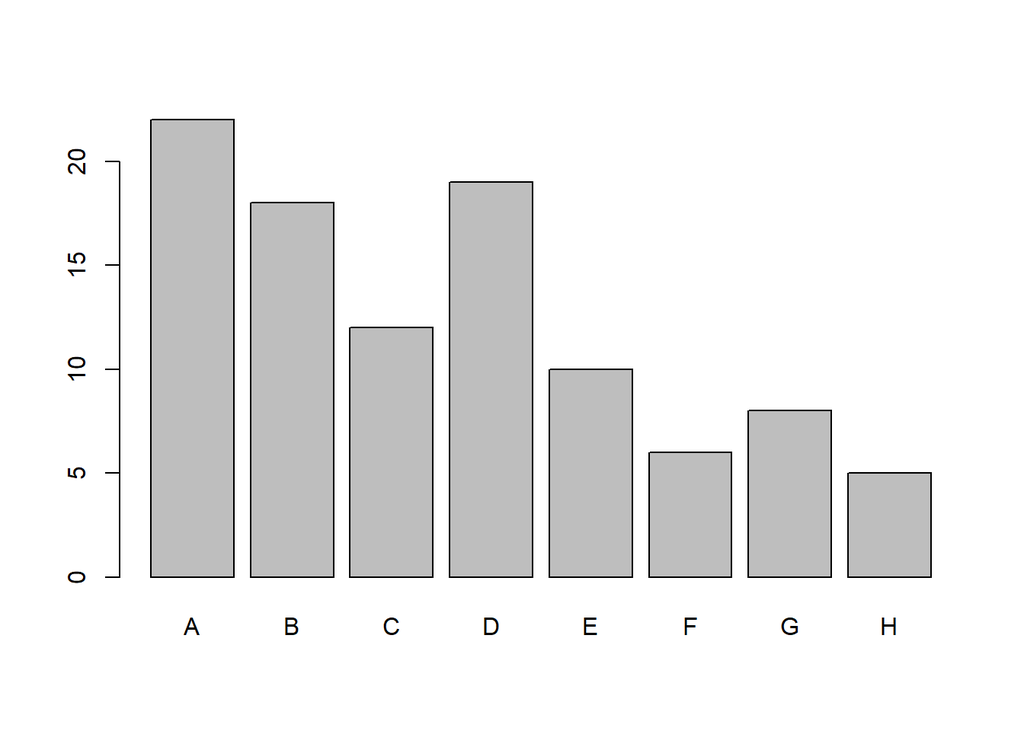

```r
x <- sample(c(1:8), 100, replace=TRUE, prob=c(8:1))
x <- table(x)
names(x) <- c("A", "B", "C", "D", "E", "F", "G", "H")
barplot(x)
```

- Piechart: pie(x)

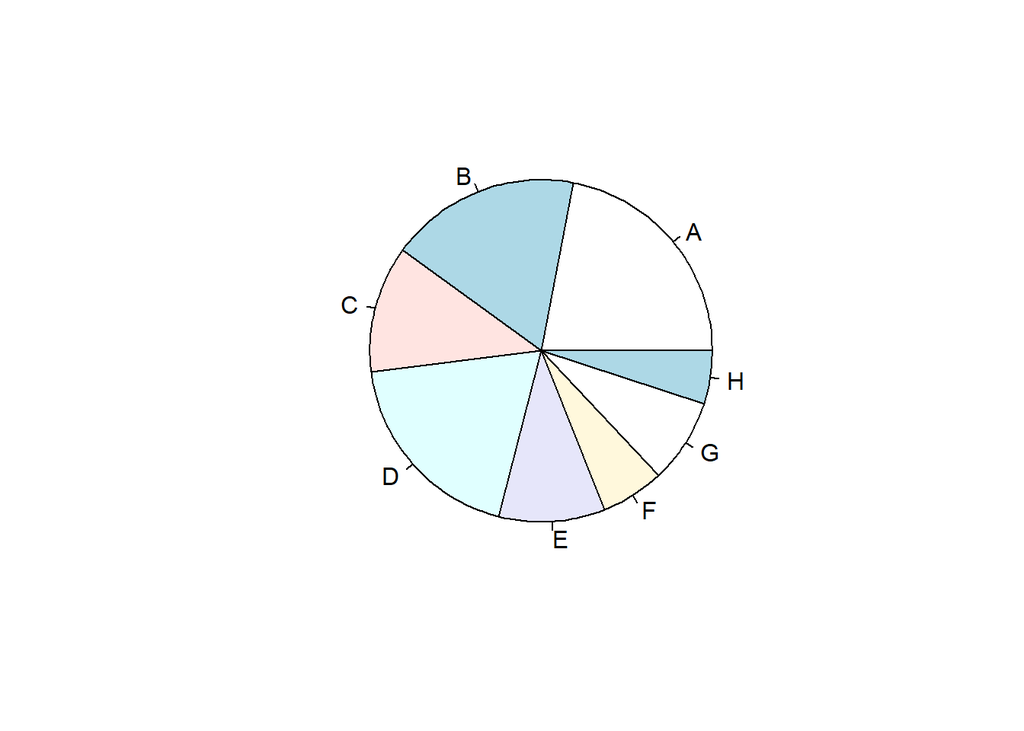

```r
pie(x)
```

- plot(x, y)

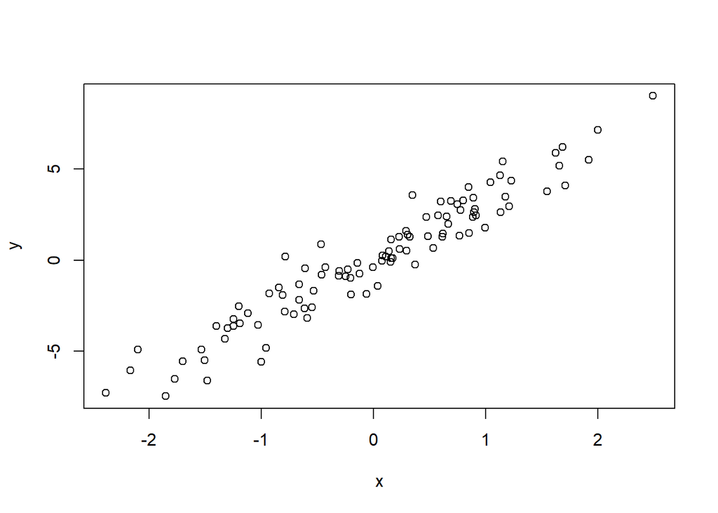

```r
x <- rnorm(100)
y <- 3*x + rnorm(100, 0, 1)
plot(x, y)
```

```r
cor(x, y)
```

```
## [1] 0.9585649
```

- Scatter plots for multiple variables: pairs(…)

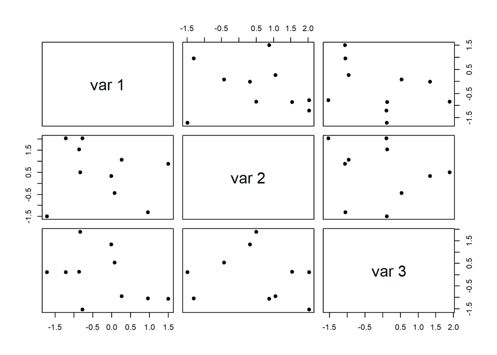

```r
X <- matrix(rnorm(30), 10, 3) ## use matrix
pairs(X, pch = 19)
```

- Boxplot for multiple categories: boxplot(x)

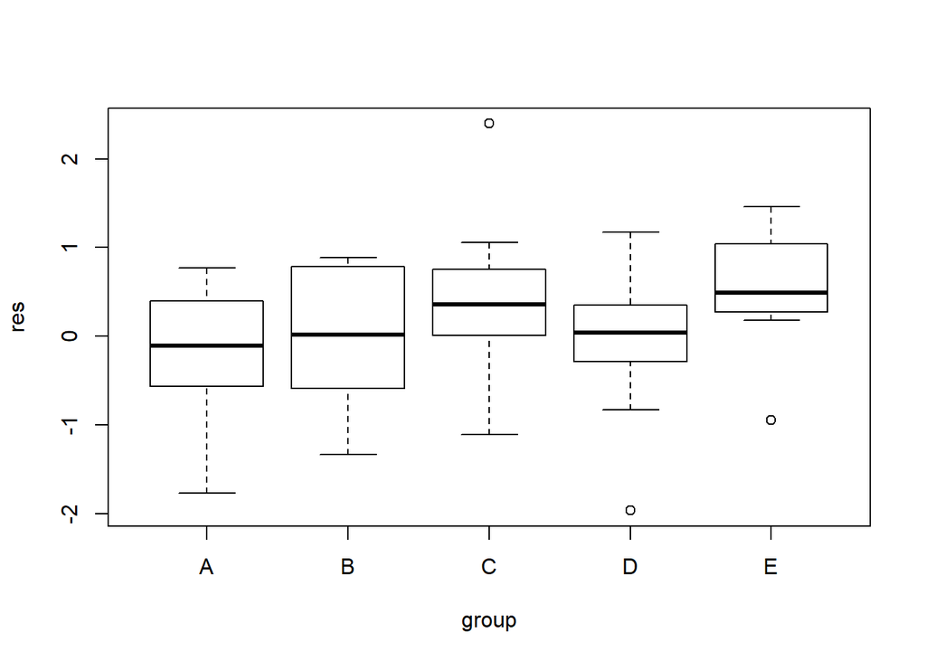

```r
X <- data.frame(group = rep(c("A", "B", "C", "D", "E"), each = 10),
res = rnorm(50))
boxplot(res ~ group, data = X)
```

> 2. general plot function: plot(…)

```
par(mfrow = c(2,3)) # split plot ranges
plot(x, y,
type = "p", ### types of the plot
pch = , ### the symbol in the plot
main = NULL, ### the title of the plot
lty = , ### the style of a line
lwd = , ### the width of a line
cex = , ### the size of an text
bty="o", ### the box around the plot
col = , ### the color of an object
xlim = NULL, ylim = NULL, # the range of an axis
sub = NULL, ### the sub-title of the plot
xlab = NULL, ylab = NULL, # the name of an axis
cex.main = ### the size of the title
)
```

```r
type = c("p", "l", "b", "s", "o", "h", "n")
```

“p”: points “l”: lines “b”: both points and lines “o”: lines pass through points “h”: the lines between points and x-axis “n”: no content in the plot but plot region “‘

- notes
  - par()：擺放圖的排法 - - -

## **Apply family**

> 1. **`apply(X, MARGIN, FUN,...)`**

Returns a vector or array or list of values obtained by applying a function to margins of an array or a matrix - **<Example 1>**

```r
A <- matrix(rnorm(1500), 500, 3)

apply(A, 2, sum); colSums(A)
```

```
## [1]  20.97615158   0.02160488 -11.16905896
```

```
## [1]  20.97615158   0.02160488 -11.16905896
```

- **<Example 2>**

```r
apply(A, 2, max)
```

```
## [1] 2.931383 2.706556 2.766555
```

```r
apply(A, 2, min, na.rm = TRUE)
```

```
## [1] -2.985496 -3.316778 -3.016715
```

- What if there are NA’s?

```r
B <- matrix(sample(1:100, 15), 5, 3)
B[1, 2] <- NA
B[3, 1] <- NA
B <- data.frame(B)
colnames(B) <- c("factor 1", "factor 2", "factor 3")
apply(B, 2, mean)
```

```
## factor 1 factor 2 factor 3
##       NA       NA       32
```

```r
apply(B, 2, mean, na.rm = TRUE)
```

```
## factor 1 factor 2 factor 3
##     29.5     33.0     32.0
```

> 2. **`lapply(X, FUN,...)`**

Returns a list of the same length as X, each element of which is the result of applying FUN to the corresponding element of X

- **<Example 1>**

```r
C <- list(a = 1:10, beta = exp(-3:3))
lapply(C, mean)
```

```
## $a
## [1] 5.5
##
## $beta
## [1] 4.535125
```

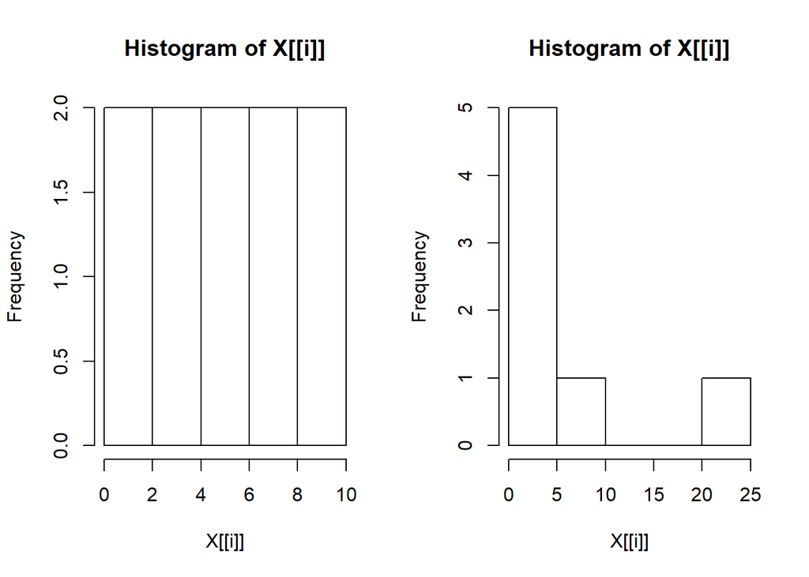

```
## $a
## $breaks
## [1]  0  2  4  6  8 10
##
## $counts
## [1] 2 2 2 2 2
##
## $density
## [1] 0.1 0.1 0.1 0.1 0.1
##
## $mids
## [1] 1 3 5 7 9
##
## $xname
## [1] "X[[i]]"
##
## $equidist
## [1] TRUE
##
## attr(,"class")
## [1] "histogram"
##
## $beta
## $breaks
## [1]  0  5 10 15 20 25
##
## $counts
## [1] 5 1 0 0 1
##
## $density
## [1] 0.14285714 0.02857143 0.00000000 0.00000000 0.02857143
##
## $mids
## [1]  2.5  7.5 12.5 17.5 22.5
##
## $xname
## [1] "X[[i]]"
##
## $equidist
## [1] TRUE
##
## attr(,"class")
## [1] "histogram"
```

```r
par(mfrow = c(1, 2))
lapply(C, hist)
```

> 3. **`sapply(X, FUN,..., simplify = TRUE)`**

```r
sapply(C, summary, simplify = FALSE)
```

```
## $a
##    Min. 1st Qu.  Median    Mean 3rd Qu.    Max.
##    1.00    3.25    5.50    5.50    7.75   10.00
##
## $beta
##     Min.  1st Qu.   Median     Mean  3rd Qu.     Max.
##  0.04979  0.25161  1.00000  4.53512  5.05367 20.08554
```

- Similarlly to lapply(X, Fun,…) if sapply(x, f, simplify = FALSE, USE.NAMES = FALSE)

```r
sapply(C, summary, simplify = FALSE)
```

```
## $a
##    Min. 1st Qu.  Median    Mean 3rd Qu.    Max.
##    1.00    3.25    5.50    5.50    7.75   10.00
##
## $beta
##     Min.  1st Qu.   Median     Mean  3rd Qu.     Max.
##  0.04979  0.25161  1.00000  4.53512  5.05367 20.08554
```

```r
lapply(C, summary)
```

```
## $a
##    Min. 1st Qu.  Median    Mean 3rd Qu.    Max.
##    1.00    3.25    5.50    5.50    7.75   10.00
##
## $beta
##     Min.  1st Qu.   Median     Mean  3rd Qu.     Max.
##  0.04979  0.25161  1.00000  4.53512  5.05367 20.08554
```

## **About Data**

> 1. Remove NA
- is.na(X)
- complete.cases(X)

```r
no.na <- complete.cases(airquality)
head(airquality[no.na,])
```

```
##   Ozone Solar.R Wind Temp Month Day
## 1    41     190  7.4   67     5   1
## 2    36     118  8.0   72     5   2
## 3    12     149 12.6   74     5   3
## 4    18     313 11.5   62     5   4
## 7    23     299  8.6   65     5   7
## 8    19      99 13.8   59     5   8
```

```r
dat.no.na.1 <- airquality[no.na,]
dim(dat.no.na.1)
```

```
## [1] 111   6
```

- na.omit(X):

```r
dat.no.na.2 <- na.omit(airquality)
dim(dat.no.na.2)
```

```
## [1] 111   6
```

> 2. Using **`cut(...)`** to group or to label items

```r
grouped2 <- cut(airquality[,3], 5,
labels = c("G1", "G2", "G3", "G4", "G5"))
head(grouped2)
```

```
## [1] G2 G2 G3 G3 G4 G4
## Levels: G1 G2 G3 G4 G5
```

- Summarize the number of each group

```r
airquality$group <- grouped2
table(grouped2)
```

```
## grouped2
## G1 G2 G3 G4 G5
## 13 57 52 28  3
```

- order the dataset by the group: **`order(...)`**_

```r
order.data.1 <- airquality[order(airquality$group),]
head(order.data.1)
```

```
##    Ozone Solar.R Wind Temp Month Day group
## 53    NA      59  1.7   76     6  22    G1
## 54    NA      91  4.6   76     6  23    G1
## 62   135     269  4.1   84     7   1    G1
## 66    64     175  4.6   83     7   5    G1
## 68    77     276  5.1   88     7   7    G1
## 80    79     187  5.1   87     7  19    G1
```

```r
order.data.2 <- airquality[order(airquality$group,
airquality$Temp), ]
head(order.data.2)
```

```
##     Ozone Solar.R Wind Temp Month Day group
## 53     NA      59  1.7   76     6  22    G1
## 54     NA      91  4.6   76     6  23    G1
## 117   168     238  3.4   81     8  25    G1
## 66     64     175  4.6   83     7   5    G1
## 62    135     269  4.1   84     7   1    G1
## 80     79     187  5.1   87     7  19    G1
```

> 3. Package: reshape2

```r
game <- c("G1", "G2", "G3", "G4", "G5")
site <- c("M", "O", "L", "O", "L")
Lin <- c(15, 6, 26, 22, 18)
Jordan <- c(18, 32, 21, 25, 12)
Peter <- c(10, 6, 22, 9, 12)
ballgames <- data.frame(game, site, Lin, Jordan, Peter)
```

- Use **`melt(data, id.vars)`** to reshape the dataset.

```r
library(reshape2)
melt(ballgames, id.vars = c("game", "site"))
```

```
##    game site variable value
## 1    G1    M      Lin    15
## 2    G2    O      Lin     6
## 3    G3    L      Lin    26
## 4    G4    O      Lin    22
## 5    G5    L      Lin    18
## 6    G1    M   Jordan    18
## 7    G2    O   Jordan    32
## 8    G3    L   Jordan    21
## 9    G4    O   Jordan    25
## 10   G5    L   Jordan    12
## 11   G1    M    Peter    10
## 12   G2    O    Peter     6
## 13   G3    L    Peter    22
## 14   G4    O    Peter     9
## 15   G5    L    Peter    12
```

- Use **`dcast(dataset, formula, fun)`** to show the specific data format.
> 4. Merge data: **`merge(...)`**
> - intersection
> - `merge(Lin.game, Jordan.game)`
- union
  - `merge(Lin.game, Jordan.game, all = TRUE)`
> 5. Regression
- Regression is used to show the relationship between independent variables and dependent variables.
- Before data analysis, we should check the relation plot

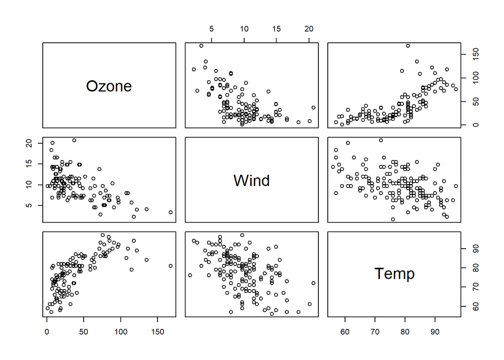

```r
pairs(airquality[,c(1,3,4)])
```

- linear model: **`lm(formula, data)`**
  - formula: y ~ x1 + x2 (with intercept)
  - formula: y ~ x1 + x2 - 1(no intercept)

```r
data1 <- airquality[1:120, ]
data2 <- airquality[121:153, ]
lm1 <- lm(Ozone ~ Temp, data = data1)
lm2 <- lm(Ozone ~ Temp - 1, data = data1)
```

- Prediction by the fitted linear model

```r
y.predict <- predict(lm1, data2)
y.predict
```

```
##       121       122       123       124       125       126       127       128
## 82.315107 87.001336 82.315107 75.285763 77.628877 79.971992 79.971992 65.913304
##       129       130       131       132       133       134       135       136
## 58.883960 49.511501 44.825271 37.795927 33.109698 51.854615 40.139042 42.482157
##       137       138       139       140       141       142       143       144
## 28.423468 28.423468 44.825271 19.051009 40.139042 21.394124 54.197730 12.021665
##       145       146       147       148       149       150       151       152
## 28.423468 51.854615 23.737239  9.678551 26.080354 42.482157 37.795927 40.139042
##       153
## 21.394124
```

- Performance of fitted model

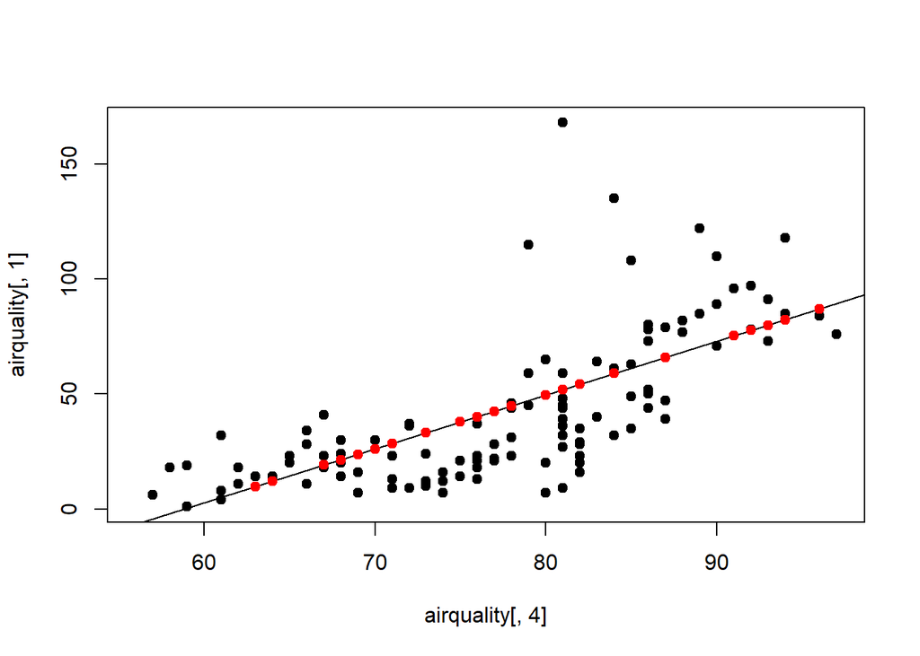

```r
plot(airquality[, 4], airquality[, 1], pch = 19)
abline(lm1)
points(airquality[121:153, 4], y.predict, col = 2, pch = 19)
```

- Performance of prediction

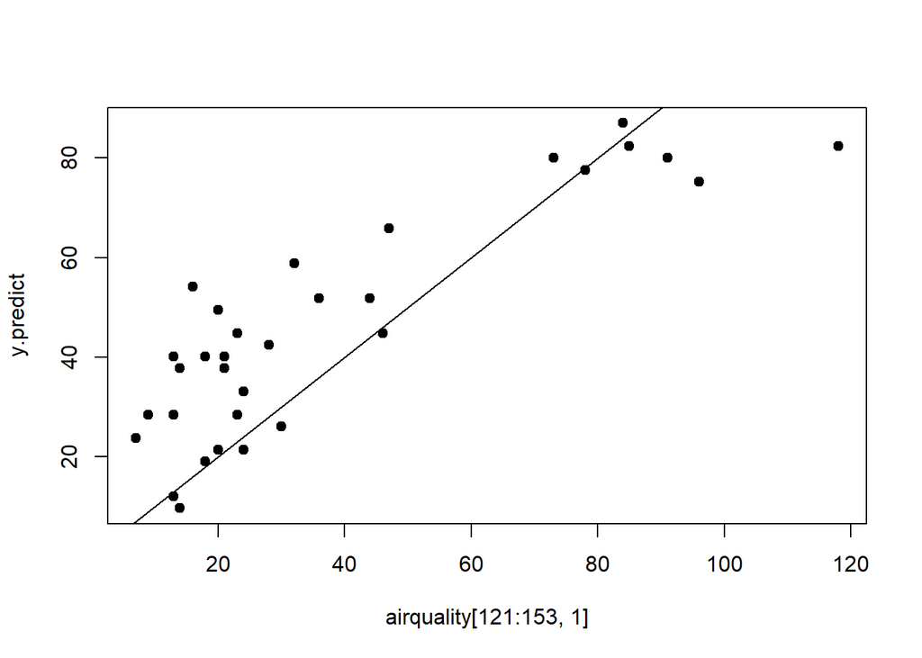

```r
plot(airquality[121:153, 1], y.predict, pch = 19)
abline(0, 1)
```

> 6. Package: dplyr

**`%>%`** means that apply functions to an object.

```r
library(dplyr)
y <- sample(1:100, 10)
mean(y)
```

```
## [1] 70.7
```

```r
y %>% mean()
```

```
## [1] 70.7
```

```r
min(y)
```

```
## [1] 22
```

```r
y %>% min()
```

```
## [1] 22
```

## **Data processing**

- **<Example 1>**

```r
train <- read.csv(file = "C:/Users/Meeting/Documents/R/reliability_training.csv")
#getwd()
head(train['Unit.ID'][1])
```

```
##   Unit.ID
## 1      F1
## 2      F1
## 3      F1
## 4      F1
## 5      F1
## 6      F1
```

```r
f1 <- sum(train['Unit.ID']=="F1")
f2 <- sum(train['Unit.ID']=="F2")
f3 <- sum(train['Unit.ID']=="F3")
f4 <- sum(train['Unit.ID']=="F4")
f5 <- sum(train['Unit.ID']=="F5")
f1+f2+f3+f4+f5
```

```
## [1] 1116
```

```r
t <- 1
for (i in train['Unit.ID']){
  t <-sum(i=="F5")
}
t
```

```
## [1] 269
```

- **<Example 2>**

```r
times <- function(n){
  roll <- c()
  for (k in 1:n){
    i <- 1
    Sum <- c()
    while (length(unique(Sum)) < 11){
      X <- sample(1:6, 1)
      Y <- sample(1:6, 1)
      Sum <- c(Sum, sum(X,Y))
      i <- i+1
      if (i > n)break
    }
    roll <- c(roll, i)
  }
  return (mean(roll))
}
times(10000)
```

```
## [1] 61.9963
```